# Adapting an (automated) Report on Gender Statistics

Regional Training on Big Data and Data Science for Gender Statistics in Asia and the Pacific

Your Name (Your Institution)

2025-04-07

In this advanced report, we will whange only one parameter *MyYear$ to have all code and text written as function of a parameter, so that changing that parameter at the very beginning of the code would consistently change the whole report.

```r
MyYear <- 2015
```

> Let’s redo the analysis for the year **2015**

**As in the previous document**, we provide here some basic elements about the data set and descriptive statistics on some variables of interest.

- First we load the data (directly from GitHub)
- Second we start exploring some variables

We will work with data on the SDG 5.5.1 indicator (“*Proportion of seats held by women in national parliaments*”) available as a CSV file from [UNSSTAT database](https://unstats.un.org/SDGS/Indicators/Database/). For easing the exercise, we stored this data set on GitHub server and use a direct download of the data set from there (*SG_GEN_PARL_ap.csv*). This report was compiled on **Monday 07 April**.

# Data exploration

The data set contains **42 observations**, and **22** variables. Let’s see also the list of countries. This information is in the variable *GeoAreaName*.

```r
ListCountries <- unique(GenderData$GeoAreaName)
ListCountries
```

```
##  [1] "Afghanistan"
##  [2] "Australia"
##  [3] "Bangladesh"
##  [4] "Bhutan"
##  [5] "Brunei Darussalam"
##  [6] "Cambodia"
##  [7] "China"
##  [8] "Democratic People's Republic of Korea"
##  [9] "Eastern Asia"
## [10] "Fiji"
## [11] "India"
## [12] "Indonesia"
## [13] "Iran (Islamic Republic of)"
## [14] "Japan"
## [15] "Kiribati"
```

[output cut: 27 more lines]

## Adapting the report for the year

The previous analysis was done for a specific year (2020). Imagine now the same report but for any year in [2010, 2020]. Let’s now do the analysis for the year that was selected!

> We have now selected the year **2015**, let’s see the *new* report!

We use the same table as before. Maybe that could be a function later ;-).

```r
# We first need to identify the variable for the selected year that we will summarize:
SelectedColumn <- paste0("X", MyYear)

# Now only for a specific year
StatsByCountryYear <- GenderData %>%
  group_by(GeoAreaName) %>%
  summarise(Percentage = .data[[SelectedColumn]]) %>% # <- This seems advanced, but works well
  arrange(desc(Percentage))
```

## As a table

We can represent the indicator as a sorted table, with highest values being on top for the year **2015**:

```r
# We will tweak a little bit the table to have a caption
MyTable <- flextable(StatsByCountryYear)
# Inserting a caption with the year
MyTable <- set_caption(MyTable, paste("Year", MyYear))
MyTable
```

Year 2015

| GeoAreaName | Percentage |
| --- | --- |
| Timor-Leste | 38.46 |
| New Zealand | 31.41 |
| Nepal | 29.48 |
| Afghanistan | 27.71 |
| Philippines | 27.24 |
| Australia | 26.67 |
| Singapore | 25.25 |
| Lao People's Democratic Republic | 25.00 |
| Viet Nam | 24.30 |
| China | 23.62 |
| Pakistan | 20.74 |
| Eastern Asia | 20.38 |
| Cambodia | 20.33 |
| Bangladesh | 20.00 |
| South-Eastern Asia | 17.84 |
| Southern Asia | 17.64 |
| Indonesia | 17.12 |
| Republic of Korea | 16.33 |
| Democratic People's Republic of Korea | 16.30 |
| Mongolia | 14.86 |
| Fiji | 14.00 |
| India | 11.97 |
| Malaysia | 10.36 |
| Japan | 9.47 |
| Kiribati | 8.70 |
| Bhutan | 8.51 |
| Tuvalu | 6.67 |
| Myanmar | 6.19 |
| Samoa | 6.12 |
| Thailand | 6.09 |
| Maldives | 5.88 |
| Sri Lanka | 5.78 |
| Nauru | 5.26 |
| Iran (Islamic Republic of) | 3.10 |
| Marshall Islands | 3.03 |
| Papua New Guinea | 2.70 |
| Solomon Islands | 2.00 |
| Micronesia (Federated States of) | 0.00 |
| Palau | 0.00 |
| Tonga | 0.00 |
| Vanuatu | 0.00 |
| Brunei Darussalam |  |

It seems that some values are missing (bottom of the table) and have been replaced by zeros. This issue should be addressed in the analysis, but we will not do it in this report.

## As a graphic

As expected, the graphic is now for the year 2015:

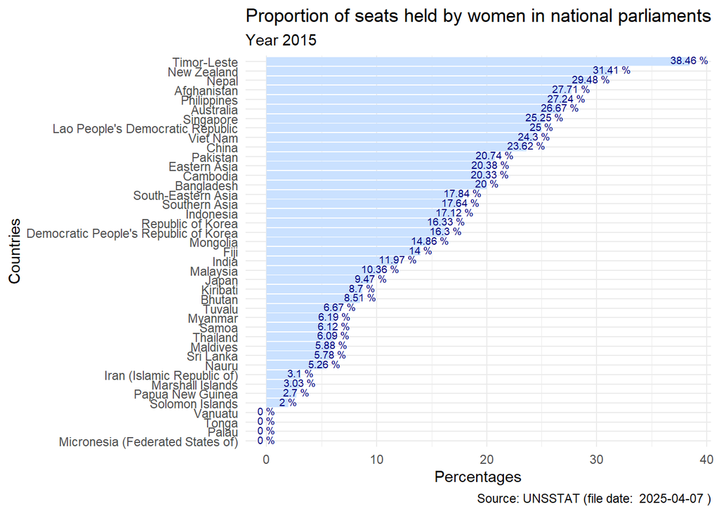

```r
StatsByCountryYear  %>%
  filter(!is.na(Percentage)) %>%  # to remove NAs
  ggplot()+
  aes(x = reorder(GeoAreaName, Percentage), y = (Percentage)) +
  geom_bar(stat = "identity",
             fill= "lightsteelblue1") +
  # we can add data to the graphic as well
  geom_text(aes(label= paste(Percentage, "%")),
            color = "navyblue", vjust= 0.3, size=2.5,)+
  labs(title ="Proportion of seats held by women in national parliaments ",
       subtitle = paste("Year",MyYear),
       caption  = paste("Source: UNSSTAT (file date: ",Sys.Date(), ")"),
       x= "Countries",
       y = "Percentages") +
  coord_flip() +
  theme_minimal()
```

# Conclusion for year 2015